# Algorithm Class - Practice 7 - Binary Tree 1

2018/7/14

# Tree Nodes

```
   8
 /   \
2     98
 \    /\
 18  1 100
```

```java
class TreeNode {
  int key;
  TreeNode left;
  TreeNode right;
  //TreeNode parent;
  //We can store parent reference as well, this will be useful for solving some problems
  public TreeNode(int key) {
    this.key=key;
  }
}
```

**LinkedList** is a special kind of Tree (if there is only one child for each of the node in the binary tree, it can be reduced to a linked list).  
Usually, we use the root to represent the binary tree.

General Tree, each node can have arbitrary number of children.

```
      5
   / / | \
  3 1  8 10
 /| |    /| \
2 4 12  6 20 9
```

```java
class TreeNode {
  int key;
  List<TreeNode> children;
  //TreeNode parent;
  public TreeNode(int key) {
    this.key = key;
    children = new ArrayList<TreeNode>();
  }
}
```

Tree is a special kind of **Graph**:

```java
class GraphNode {
  int key;
  List<GraphNode> neighbors;
  public GraphNode(int key) {
    this.key = key;
    neighbors = new ArrayList<GraphNode>();
  }
}
```

List<GraphNode>

**Other representation: Adjacency list**

Vertices are stored as records or objects, and every vertex stored a list of adjacent vertices. This data structure allows the storage of additional data on the vertices. Additional data can be stored if edges are also stored as objects, in which case each vertex stores its incident edges and each edge stores its invident vertices.

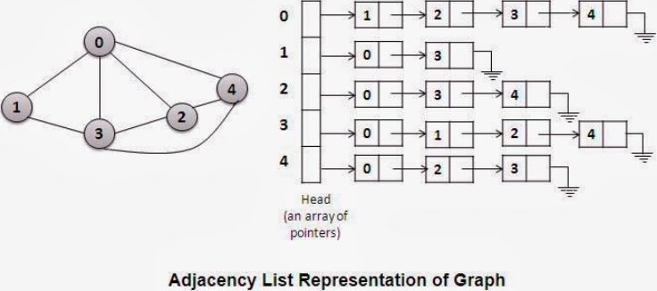

```java
class GraphNode {
  int key;
  List<GraphNode> neighbors;
  public GraphNode(int key) {
    this.key = key;
    neighbors = new Arraylist<GraphNode>();
  }
}
GraphNode node0 = new GraphNode(0);
GraphNode node1 = new GraphNode(1);
//...
node0.neighbors.add(node1);
node0.neighbors.add(node2);
node0.neighbors.add(node3);
node0.neighbors.add(node4);
node1.neighbors.add(node0);
node1.neighbors.add(node3);
//...
```

When coding, you can use integers to represent vertex. In this way, a graph can be represented as:

List<List<Integer>>

graph.get(1) -> Node 1’s neighbors  
graph.get(2) -> Node 2’s neighbors  
...  
graph.get(i) -> Node i’s neighbors

```java
for (Integer i : graph.get(1)) {
  //i is a neighbor of node 1
}
```

# Traversals of Binary Tree

- preorder: root, left sub, right sub
- inorder: left sub, root, right sub
- postorder: left sub, right sub, root

List LinkedList, General ways of solving problems about binary (search) tree:

**Recursive**

divide and conquer is nature of binary tree - binary tree can be easily divided into three parts

- solve problem for left/right subtree
- solve the problem for root

**Iterative**

- could be complicated for binary tree but we need to know how

Level order traversal: Try to build one for your LaiCode test cases.

# Binary Search Tree

Binary Search Tree is a binary tree maintains the following property: for any of the nodes in the binary tree, all the nodes in its right subtree is larger than itself, all the nodes in its left subtree is smaller than itself (compared by the key stored in each of the nodes).

```
   10
 /    \
5      15
 \    /  \
  8  14  16
 / \
6   9
```

## Basic Operations of Binary Search Tree

- `search()` - worst case O(n), average O(log n)
- `insert()` - worst case O(n), average O(log n)
- `remove()` - worst case O(n), average O(log n)

## Balanced Binary Search Tree

`search()`, `insert()`, `remove()` operations are all guaranteed to be O(log n).

e.g. AVL Tree, Red-Black Tree, etc.

Red-Black tree

- in Java: TreeMap/TreeSet
- in C++: map/set

We are not going to implement balanced binary search tree, instead we are more interested in basic implementation.

## Search BST

```
   10
 /    \
5      15
 \    /  \
  8  14  16
 / \
6   9
```

```java
class TreeNode {
  int key;
  TreeNode left;
  TreeNode right;
  public TreeNode(int key) {
    this.key=key;
  }
}
```

**Recursive**

```java
public TreeNode search(TreeNode root, int target) {
  //1. process root
  if (root == null || root.key == target) {  //terminate condition
    return root;
  }
  //2. check left node if target less than root.key
  if (target < root.key) {
    return search(root.left, target);  //break point
  }
  //3. check right node if target greater than root.key
  else {
    return search(root.right, target);
  }
}
```

**Tail Recursion**

The recursive call is always the last execution statement.

We can easily transfer the tail recursion to iterative solution.

```
                         root
         /                |                   \
terminate              return                 return
condition    search(root.left, target)    search(root.right, target)
```

Not a tail recursion:

```java
return isBst(root.left, ...) && isBst(root.right, ...);
```

**Iterative**

```java
public TreeNode search(TreeNode root, int target) {
    TreeNode currentNode = root;
    while (currentNode != null && currentNode.key != target) {  //terminate condition
      if (target < currentNode.key) {
        currentNode = currentNode.left;
      }
      else {
        currentNode = currentNode.right;
      }
    }
    //exit while loop: currentNode = null || currentNode.key == target
    return currentNode;
}
```

## Insert in BST

```
       10
   /        \
  5          15
 / \        /  \
4   8      14  17
   / \    /
  6   9  11
```

**Recursion**

- A very common way when the tree structure could be changed, in this case, we return the **new root** after the change (remind about the same case of Linked List?).

```java
public TreeNode insert(TreeNode root, int key) {
  if (root == null) {
    TreeNode newRoot = new TreeNode(key);
    return newRoot;
  }
  if (root.key < key) {
    root.right = insert(root.right, key);
  }
  else if (root.key > key) {
    root.left = insert(root.left, key);  //break point
  }
  return root;
}
```

```
          root
         /    \ (root.key < key)
terminate    root.right = insert(root.right, key);
             return root;
```

**Recursion 2 (Remove redundant operation)**

```java
public static TreeNode insert(TreeNode root, int target) {
  if (root == null) {
    return new TreeNode(target);
  }
  helper(root, target);
  return root;
}

public static void helper(TreeNode root, int target) {
  if (target == root.key) {
    return;
  }
  else if (target < root.key) {
    if (root.left == null) {
      root.left = new TreeNode(target);
    }
    else {
      helper(root.left, target);
    }
  }
  else {
    if (root.right == null) {
      root.right = new TreeNode(target);
    }
    else {
      helper(root.right, target);
    }
  }
}
```

1. `(target == root.key) return; //terminate`
2. `target < root.key`:
   1. `root.left == null`: `root.left = new TreeNode(target); //terminate`
   2. `else`: `helper(root.left, target);`
3. `target > root.key`:
   1. `root.right == null`: `root.right = new TreeNode(target); //terminate`
   2. `else`: `helper(root.right, target);`

**Iterative**

```java
public TreeNode insert(TreeNode root, int target) {
  TreeNode newNode = new TreeNode(target);
  if (root == null) {
    return newNode;
  }
  TreeNode current = root;
  while (current.key != target) {
    if (current.key > target) {
      if (current.left != null) {
        current = current.left;
      }
      else {
        current.left = newNode;
        break;
      }
    }
    else {
      if (current.right != null) {
        current = current.right;
      }
      else {
        current.right = newNode;
        break;
      }
    }
  }
  return root;
}
```